# Analysing Phone Usage on the Bus

## What is my data about?

This data explores the mobile phone usage among people on the bus. It was collected by observing the proportion of people using their phones at different times of days, across weekends and weekdays. Analyzing these patterns allowed us to see how phone usage changes depending on the time of day or type of day, giving insight to our behaviors.

## Phone usage by Time of Day

The bar chart shows the average proportion of people using their phones at different times of the day. Early morning (5am to 9am) had the highest average, suggesting people are more likely to use their phones during the morning to maybe check messages, emails, scroll social media or to just pass time.

Afternoon travel (12pm to 5pm) showed relatively high phone usage, but as the day goes on it slightly decreases.This could be due to people being more tired and just wanting to rest on the bus.

Morning (9am - 12pm) had the lowest average phone usage, suggesting shorter travel times.

This chart suggests that phone usage on the bus changes depending on the time of day.

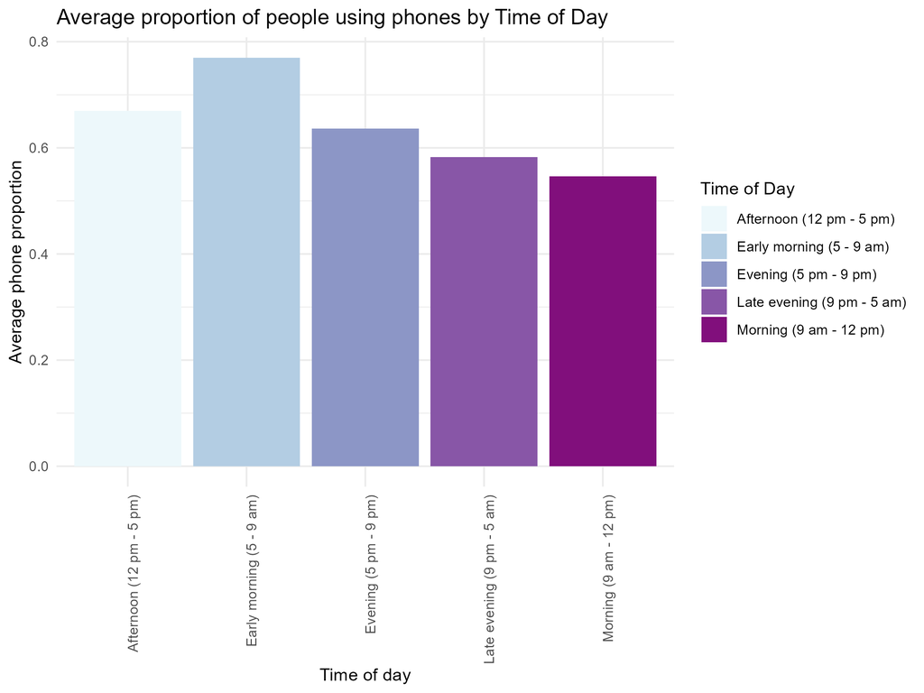

Bar chart of average proportion of phone usage by time of day

## Phone usage by hour of day.

The line chart shows the average proportion of people on their phones on the bus at different hours of the day. Phone usage is higher around 8am suggesting people are more likely to use their phones to check messages, emails and other stuff during the morning.

Around 10am a few hours past, phone usage decreasing suggesting less reliance on phones during those times.

After 6pm, we see another increase in phone usage, reaching a peak at 8pm. This suggests that people in the evening are likely to use their phones for entertainment on the way home from work, school or anywhere else.

This chart shows that phone usage on public transport changes depending on the hour of the day.

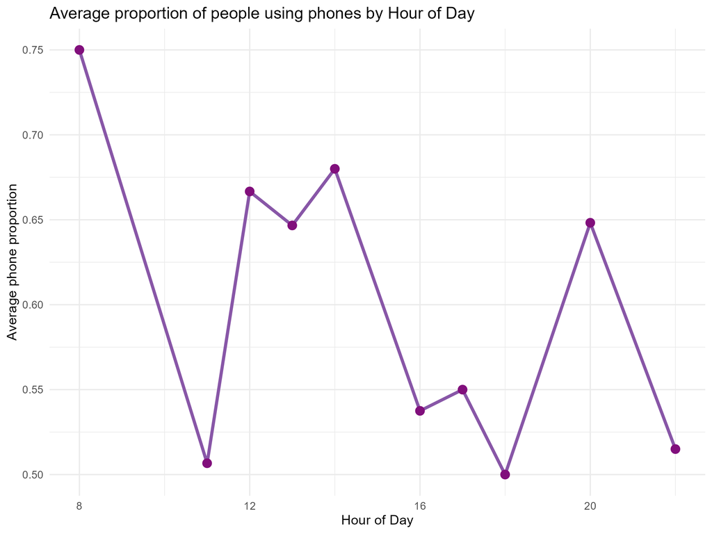

Line chart of average proportion of phone usage by Hour of Day